# 90 Years of Harvard Business Review

> Bare lists of words are found suggestive to an imaginative and excited mind.  
> -Ralph Waldo Emerson, writer and philosopher (1803-1882) (thanks to [a.w.a.d](http://wordsmith.org/awad/))

I'm working on the Harvard Business Review data set (a [kaggle](http://www.kaggle.com/) [thing](https://www.kaggle.com/c/harvard-business-review-vision-statement-prospect/)). I want to make the timeline more physically intuitive and more closely linked to the pages of HBR. I'm using R with knitr (R markdown) to show my work. I'm Aaron Schumacher and I welcome any comments, corrections, suggestions, etc.

```r
# set up graphics for later
suppressPackageStartupMessages(library(ggplot2))
theme_set(theme_bw())

# Read in the provided file, available at the kaggle site
# https://www.kaggle.com/c/harvard-business-review-vision-statement-prospect/data
hbr <- read.csv('HBR Citations_correct_abstracts.csv',
              strip.white=TRUE,
              as.is=TRUE)
# This was working fine for a while and then something went wrong somehow with
# some unicode characters or something, so I had to do this on the command line:
# LC_CTYPE=C tr -c -d "[:alnum:][:punct:][:space:]" \
# < 'HBR Citations_correct_abstracts.csv' > hbr.csv
# cp 'HBR Citations_correct_abstracts.csv' original.csv
# mv hbr.csv 'HBR Citations_correct_abstracts.csv'
# That filtering only took out two bytes. Not an issue.
# Your mileage may vary.

# make sure we've got the expected number of observations
# as checked against the Excel files that were originally provided
stopifnot(nrow(hbr)==12751)

# confirm that there's always at most one of
# ABSTRACT or AUTHOR.SUPPLIED.ABSTRACT
stopifnot(all(hbr$ABSTRACT=="" | hbr$AUTHOR.SUPPLIED.ABSTRACT==""))
# and put it in a more convenient place
hbr$abstract <- ifelse(hbr$ABSTRACT!="",hbr$ABSTRACT,hbr$AUTHOR.SUPPLIED.ABSTRACT)
# preserve information just in case
hbr$abstract_type <- ifelse(hbr$ABSTRACT!="","HBR",
                            ifelse(hbr$AUTHOR.SUPPLIED.ABSTRACT!="","author",
                                   "none"))

# fix up the dates
# without this you incorrectly get results like year 2068, etc...
# the substringing only works because all the dates are 8 character
stopifnot(all(nchar(hbr$SYSTEM..PUB.DATE)==8))
hbr$dm <- substr(hbr$SYSTEM..PUB.DATE,1,6)
hbr$y <- substr(hbr$SYSTEM..PUB.DATE,7,8)
hbr$dmY <- ifelse(as.numeric(hbr$y)>20,
                  paste(hbr$dm,"19",hbr$y,sep=""),
                  paste(hbr$dm,"20",hbr$y,sep=""))
hbr$date <- as.Date(hbr$dmY,format="%d-%b-%Y")
hbr$year <- as.numeric(substr(hbr$date,1,4))
```

The first issue seems to have been published `1922-10-01`. Everyone seems to agree on the year, at least. The [HBR wikipedia page](http://en.wikipedia.org/wiki/Harvard_Business_Review) adds this interesting tidbit:

> Harvard Business Review began in 1922 as a magazine for Harvard Business School. Founded under the auspices of Dean Wallace Donham, HBR was meant to be more than just a typical school publication. “The paper [HBR] is intended to be the highest type of business journal that we can make it, and for use by the student and the business man. It is not a school paper,” Donham wrote.

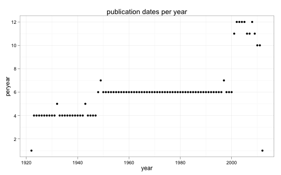

```r
# columns "VOLUME", "ISSUE", and "PUBLICATION.DATE", which has something like
# volume names, are all moderately interesting,
# but I'll be mostly concerned with publication dates as pulled out above

# How often is HBR published?
years <- sort(unique(hbr$year))
dpy <- data.frame("year"=years,
                  "peryear"=sapply(years,function(x) {
                    length(unique(hbr$date[hbr$year==x]))
                    }))
qplot(year, peryear, data=dpy, main="publication dates per year")
```

There's some fluctuation from special supplements and just irregularities, but broadly it was quartlerly, then bi-monthly, then close to monthly (10, 11, or 12 times per year). I'll pull out the years that start the second and third epochs.

```r
# start of bi-monthly epoch
head(dpy[dpy$peryear==6,],1)
```

```
##    year peryear
## 27 1948       6
```

```r
# start of near-monthly epoch
head(dpy[dpy$peryear==11,],1)
```

```
##    year peryear
## 80 2001      11
```

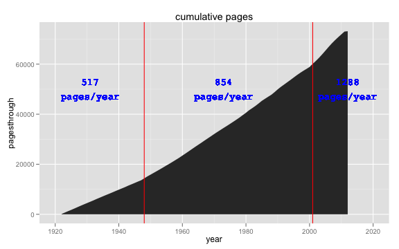

```r
# let's look at page counts and word counts
hbr$pagesN <- hbr$PAGE.COUNT
# maybe it would be better to use "START.PAGE" and "END.PAGE"
# I don't think it's worth checking into that
# Let's look at page counts through time
pty <- data.frame("year"=years,
                  "pagesthrough"=sapply(years,function(x) {
                    sum(hbr$pagesN[hbr$year<=x], na.rm=TRUE)
                    }))
ggplot(pty, aes(year, pagesthrough)) +
  geom_area() +
  opts(title="cumulative pages") +
  geom_vline(xintercept=c(1948,2001), colour=I("red")) +
  geom_text(x=1931, y=50000,
            label=paste(round(sum(hbr$pagesN[hbr$year<1948&hbr$year>1922],na.rm=TRUE)/
              (1948-1922)),"pages/year",sep="\n"),
            colour=I("blue"), family="mono") +
  scale_x_continuous(limits=c(1920,2020)) +
  geom_text(x=1973, y=50000,
            label=paste(round(sum(hbr$pagesN[hbr$year<2001&hbr$year>=1948],na.rm=TRUE)/
              (2001-1948)), "pages/year",sep="\n"),
            colour=I("blue"), family="mono") +
  geom_text(x=2012, y=50000,
            label=paste(round(sum(hbr$pagesN[hbr$year<2012&hbr$year>=2001],na.rm=TRUE)/
              (2012-2001)), "pages/year",sep="\n"),
            colour=I("blue"), family="mono")
```

It looks like the changes in publishing frequency were not offset by too much thinning of individual issues. (I won't try to dig into words per year.)

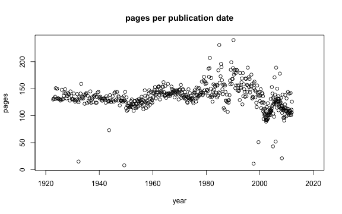

```r
# ugly, but it works; look at the output
with(hbr, plot(sort(unique(date)),tapply(pagesN,date,sum,na.rm=TRUE)[order(names(tapply(pagesN,date,sum,na.rm=TRUE)))],xlim=as.Date(c("1920-01-01","2020-01-01")),xlab="year",ylab="pages",main="pages per publication date"))
```

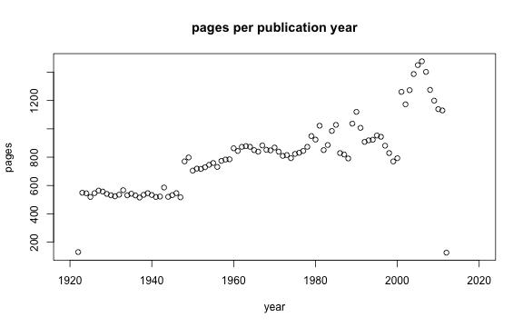

```r
with(hbr, plot(sort(unique(year)),tapply(pagesN,year,sum,na.rm=TRUE)[order(names(tapply(pagesN,year,sum,na.rm=TRUE)))],xlim=c(1920,2020),xlab="year",ylab="pages",main="pages per publication year"))
```

Well, it looks like there was some drop in issue thickness when HBR went to the near-monthly frequency in 2001. But doubling (or nearly so) the frequency gave the highest ever yearly page counts. Here's how to space out the year labels in the combined anthology of all HBR ever, which is how to space out my timeline weighted by HBR commentary.

```r
pty$mark <- c(0, pty$pagesthrough / max(pty$pagesthrough))[-(nrow(pty)+1)]
print(pty,row.names=FALSE)
```

```
##  year pagesthrough     mark
##  1922          130 0.000000
##  1923          679 0.001777
##  1924         1224 0.009282
##  1925         1743 0.016732
##  1926         2289 0.023826
##  1927         2853 0.031290
##  1928         3410 0.039000
##  1929         3951 0.046614
##  1930         4482 0.054009
##  1931         5006 0.061268
##  1932         5541 0.068431
##  1933         6108 0.075744
##  1934         6639 0.083495
##  1935         7181 0.090754
```

[output cut: 77 more lines]

I can't say for sure how many words were on pages before 1990, but I would like to estimate a total word count. Here's an attempt:

```r
hbr$wordsN <- hbr$FULL.TEXT.WORD.COUNT
```

There are `12751` entries total. Of these, `12549` have a page count, but only `5654` have a word count. (They started counting in `1990`.) All but `13` of the entries with word counts have page counts. Based on those entries, there's an average of `541.4908` words per page. At least [some people online](http://www.writersservices.com/wps/p_word_count.htm) think that's reasonable.